# HW4 - A Tale Of War (Project Proposal)

Cynthia Clement & Vineet Aguiar

## Q1) Introduction

**Overview**  
Wars are complex events born of geopolitical, cultural or economic strife, oftentimes spanning many years but ultimately costing us lives, our livelihood and peace. During wars, countries quickly adopt ideologies, form allegiances, and discipline their economic and scientific priorities while maintaining their military focus with a blind adherence. Although the causes of this displacement of peace may vary, is there a precursory pattern to it? Does the landscape change after the end of a prolonged conflict? Do certain actors benefit more? Do some lose more than others? And most importantly, could there be important predictors of these epic events that change the course of history?

**Our Aim**  
We are particularly interested in studying the changes that happen to a country before and after they enter a war. We want to see the change of alliances and strategies, it’s impact on trade and commerce and the economics at play. We also want to compare and contrast the characteristics of countries who won wars with the ones that lost. Our eventual goal is to find certain factors that indicate which countries will enter into a war and how these factors/predictors change over time.

**Scope and Timeline**  
To limit our scope we will explore the data with a particular emphasis on the United States of America and the wars it has fought since 1900. At various points, we may have to include comparisons between countries and the US and we will explore the data breadth-wise to draw meaningful insights.

For our timeline, we plan to look at events/activity leading to, during and following the major US wars, namely;  
WWI ————————– 1914-1918  
WWII ————————- 1939-1945  
Cold War ——————– 1947-1991  
Korean War —————- 1950-1953  
Vietnam War ————— 1955-1975  
War in Afghanistan ——- 2001-2010

## Q2) The Data, Team Members and The Roles

The [Correlates of War Project](http://www.correlatesofwar.org) is a treasure trove of information. We have a special interest in the following datasets: Trade, National Materials Capabilities, Alliances and Militarized Interstate Disputes.

**Our Plan**  
We’ve decided to divide and conquer the work by each taking a subset of the data and exploring it. After sometime, we will regroup to see what we’ve learnt so far and switch data sets amongst ourselves to see if there are more insights to be learnt or different approaches to visualize the existing data. Lastly, we want to drill down into particular variables and plot correlations or predictors for the final output.

*Phase 1:*  
* Cynthia to analyze National Materials Capabilites and Alliances  
* Vineet to analyize Militarized Interstate Disputes and Trade

*Phase 2:*  
* We are going to switch the data sets we are looking at to see if the other person can discern any new insights or creative ways of presenting the data.  
+ Cynthia to analyze Militarized Interstate Disputes and Trade  
+ Vineet to analyze National Materials Capabilites and Alliances

*Phase 3:* * Cynthia and Vineet to come together and look at the interaction of different variables. For examply how did a change in trade impact the NMC.

## Q3) Initial Exploration

##### NMC

National Material Capabilities(NMC) is the measure ofthe power of a country based on 6 values: military expenditure, military personnel, energy consumption, iron and steel production, urban population, and total population. To view the these 6 metrics and a single indicator, we use the Composite Indicator of National Capability(CINC). We believe that this indicator can reveal certain characters that can help determine the outcome of a war.

We started by looking at the general trend of the 6 varaibles for some of the major powers today.

```r
## Set file path
#path = "/Users/cynthiaclement/Desktop"
path = "/home/vaguiar/col_hw/vis_hw/final/data/"
member_alliances = read.csv(paste(path, "version4.1_csv/alliance_v4.1_by_member.csv", sep= "/"))
NMC = read.csv(paste(path, "NMC/NMC_v4_0.csv", sep= "/"))
## cleaning the unknown values to 0
NMC$cinc[NMC$cinc == -9] <- 0
NMC$irst[NMC$irst == -9] <- 0
NMC$milex[NMC$milex == -9] <- 0
NMC$milper[NMC$milper== -9] <- 0
NMC$pec[NMC$pec == -9] <- 0
NMC$tpop[NMC$tpop == -9] <- 0
NMC$upop[NMC$upop == -9] <- 0
## import dataset of yeard
timeline <- usevents
```

[output not shown]

```r
ggplot(nmc_c[nmc_c$year > yr_min,], aes(year , cinc, color = stateabb, group = stateabb)) + geom_point(alpha = 1/100) + geom_line()  + theme(axis.text.x = element_text(angle = 90, hjust = 1), plot.title = element_text(hjust = 0.5)) + ggtitle("Composite National Materials Capabilities")
```

[output not shown]

```r
## Heatmap of CNIC

ggplot(nmc_c[nmc_c$year > 1900,], aes(stateabb, year, fill = cinc)) + geom_tile()+
  scale_fill_viridis() + ggtitle("Heatmap of cinc") + theme(axis.text.x = element_text(angle = 60, hjust = 1),plot.title = element_text(hjust = 0.5))
```

[output not shown]

```r
##PCP PLot
library(GGally)
ct <- ggparcoord(nmc_c[nmc_c$year>1930,], columns = 4:10, scale = "uniminmax", alphaLines = .2, groupColumn = "stateabb")
yr <- ggparcoord(nmc_c[nmc_c$year>1930,], columns = 4:10, scale = "uniminmax", alphaLines = .2, groupColumn = "year")
grid.arrange(ct, yr, nrow = 2)
```

[output not shown]

##### Trade

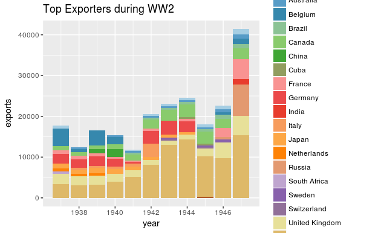

```r
library(ggplot2)
library(dplyr)
library(RColorBrewer)
# Reading both raw DataSets -
nat_trade <-read.csv(file="./data/COW_Trade_4.0/National_COW_4.0.csv", head=TRUE, sep=",")
#dyad_trade <-read.csv(file="./data/COW_Trade_4.0/Dyadic_COW_4.0.csv", head=TRUE, sep=",")
#Using Dict values
WW2_start <- 1939
WW2_end <- 1945
# Filtering data for the years for WW2 and 2 years before & after.
nat_trade <- nat_trade[nat_trade$year >= (WW2_start-2), ]
nat_trade <- nat_trade[nat_trade$year <= (WW2_end+2), ]
#dyad_trade <- dyad_trade[dyad_trade$year > (WW2_start-2) ,]
#dyad_trade = dyad_trade[dyad_trade$year < (WW2_end+2), ]
# Top 10 exporters in the war years
nat_top10_exp <- data.frame(colnames(nat_trade))
#print(nat_top10_exp)
for(yr in (WW2_start-2):(WW2_end+2))
{
  nat_top10_yr <- head(arrange(filter(nat_trade, year == yr), desc(exports)), 10)

  if(yr == (WW2_start-2))
    nat_top10_exp <- nat_top10_yr
  else
    nat_top10_exp <- rbind(nat_top10_exp, nat_top10_yr)
}
#print(nat_top10_exp)
#Using distinct color palette
cols <- colorRampPalette(brewer.pal(12, "Paired"))
myPal <- cols(length(unique(nat_top10_exp$statename)))
ggplot(nat_top10_exp, aes(x = year, y = exports, fill = statename)) +
  geom_bar(stat="identity") +
  scale_fill_manual(values = myPal) +
  ggtitle("Top Exporters during WW2")
```

```r
NA
```

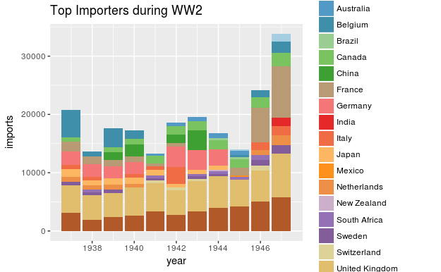

```r
# Top 10 importers in the war years
nat_top10_imp <- data.frame(colnames(nat_trade))
for(yr in (WW2_start-2):(WW2_end+2))
{
  nat_top10_yr <- head(arrange(filter(nat_trade, year == yr), desc(imports)), 10)

  if(yr == (WW2_start-2))
    nat_top10_imp <- nat_top10_yr
  else
    nat_top10_imp <- rbind(nat_top10_imp, nat_top10_yr)
}
#print(nat_top10_imp)
#Using distinct color palette
cols <- colorRampPalette(brewer.pal(12, "Paired"))
myPal <- cols(length(unique(nat_top10_imp$statename)))
ggplot(nat_top10_imp, aes(x = year, y = imports, fill = statename)) +
  geom_bar(stat="identity") +
  scale_fill_manual(values = myPal) +
  ggtitle("Top Importers during WW2")
```